5 min read

# Is it CR7 or Messi?

2018/06/01

# World Cup Mode: CR vs Messi

To try to solidify what I have learned from Deep Learning for coders from fast.ai, I'll try to train a computer vision algorithm such that it can recognize whether is Messi or Cristiano Ronaldo in the picture. [Notebook in github](https://github.com/David-Salazar/deep_learning-fast.ai/blob/master/Cr_vs_Messi.ipynb) or [nbviewer](http://nbviewer.jupyter.org/github/David-Salazar/deep_learning-fast.ai/blob/master/Cr_vs_Messi.ipynb)

## Imports

```python
# Put these at the top of every notebook, to get automatic reloading and inline plotting
%reload_ext autoreload
%autoreload 2
%matplotlib inline
```

```python
# This file contains all the main external libs we'll use
from fastai.imports import *
```

```python
from fastai.transforms import *
from fastai.conv_learner import *
from fastai.model import *
from fastai.dataset import *
from fastai.sgdr import *
from fastai.plots import *
```

## Create your own dataset

Using the wonderful [`googleimages`](https://github.com/hardikvasa/google-images-download) from fast.ai student Hardik Vasa, this is extremely easy running shell comands. For example

```python
#! googleimagesdownload -k "cr7, messi" -f jpg -l 100 -o train
```

The above shell comand will download for each of the keywords 100 .jpg images and will put them on the folder train. Cannot be easier!

## Fast.ai workflow

```python
PATH = "cr_vs_messi/"
sz=224
arch=resnet34
bs = 64
```

```python
!ls {PATH}
```

```
train  valid
```

```python
data = ImageClassifierData.from_paths(PATH, tfms=tfms_from_model(arch, sz))
```

```python
fn = PATH+ data.trn_ds.fnames[100]; fn
```

```
'cr_vs_messi/train/cr7/6. cristiano-ronaldo-of-real-madrid-celebrates-after-scoring-a-goal-the-picture-id481747786?s=612x612.jpg'
```

[figure not shown]

```python
img = PIL.Image.open(fn); img
```

Great picture :) (big Real Madrid fan, here). Let's find our images' sizes:

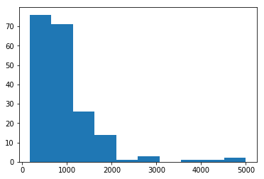

```python
size_d = {k: PIL.Image.open(PATH+k).size for k in data.trn_ds.fnames}
row_sz, col_sz = list(zip(*size_d.values()))
row_sz = np.array(row_sz)
col_sz = np.array(col_sz)
plt.hist(row_sz)
```

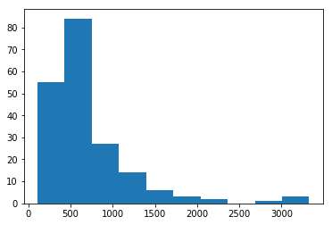

```python
plt.hist(col_sz)
```

Seems images are a little big bigger than we are used to.

## Training

Training with fast.ai is as simple and fast as it could possibly be. When training neural networks for computer vision, it is always best to use a pretrained network (usually on ImageNet). Thus, we use a whole network pre-trained, take out the final layer of prediction, and use the weights that have learned to identify certain features as the first part of our own neural network. Above those, we add further layers of our own to predict.

```python
learn = ConvLearner.pretrained(arch, data, precompute=True)
learn.fit(0.01, 2)
```

```
epoch      trn_loss   val_loss   accuracy
    0      0.98899    0.50631    0.85
    1      0.728332   0.327768   0.833333
```

```
[0.3277679681777954, 0.8333333134651184]
```

Let's see what the above accuracy on validation (83.3%) looks like with actual images. Note that these results are with just two epochs and not doing anything about the learning rate nor doing any data augmentation.

```python
log_preds = learn.predict()
preds = np.argmax(log_preds, axis=1)  # from log probabilities to 0 or 1
probs = np.exp(log_preds[:,1])
def rand_by_mask(mask): return np.random.choice(np.where(mask)[0], 4, replace=False)
def rand_by_correct(is_correct): return rand_by_mask((preds == data.val_y)==is_correct)
def plot_val_with_title(idxs, title):
    imgs = np.stack([data.val_ds[x][0] for x in idxs])
    title_probs = [probs[x] for x in idxs]
    print(title)
    return plots(data.val_ds.denorm(imgs), rows=1, titles=title_probs)
def plots(ims, figsize=(12,6), rows=1, titles=None):
    f = plt.figure(figsize=figsize)
    for i in range(len(ims)):
        sp = f.add_subplot(rows, len(ims)//rows, i+1)
        sp.axis('Off')
        if titles is not None: sp.set_title(titles[i], fontsize=16)
        plt.imshow(ims[i])
def load_img_id(ds, idx): return np.array(PIL.Image.open(PATH+ds.fnames[idx]))

def plot_val_with_title(idxs, title):
    imgs = [load_img_id(data.val_ds,x) for x in idxs]
    title_probs = [probs[x] for x in idxs]
    print(title)
    return plots(imgs, rows=1, titles=title_probs, figsize=(16,8))
```

```
Correctly classified
```

[figure not shown]

```python
# 1. A few correct labels at random
plot_val_with_title(rand_by_correct(True), "Correctly classified")
```

Note that the higher the probability, we are saying that it is likely that this image is the current Ballon d'Or ;).

```
Incorrectly classified
```

[figure not shown]

```python
# 2. A few incorrect labels at random
plot_val_with_title(rand_by_correct(False), "Incorrectly classified")
```

```
Most correct Messi
```

[figure not shown]

```python
def most_by_mask(mask, mult):
    idxs = np.where(mask)[0]
    return idxs[np.argsort(mult * probs[idxs])[:4]]

def most_by_correct(y, is_correct):
    mult = -1 if (y==1)==is_correct else 1
    return most_by_mask(((preds == data.val_y)==is_correct) & (data.val_y == y), mult)

plot_val_with_title(most_by_correct(0, True), "Most correct Messi")
```

The results seem ok. However, we could do a lot better. Let's tinker with the model

### Learning Rate

The learning rate determines how quickly or how slowly you want to update the weights (or parameters). Learning rate is one of the most difficult parameters to set, because it significantly affects model performance.

```python
#lrf=learn.lr_find()
```

However, due to the the low amount of data we are working with, much tinkering with the learning rate, whether is annealing or any other, won't be much promising. Instead, let's work with the promising feature of data augmentation.

### Data Augmentation

[figure not shown]

```python
tfms = tfms_from_model(resnet34, sz, aug_tfms=transforms_side_on, max_zoom=1.1)
def get_augs():
    data = ImageClassifierData.from_paths(PATH, bs=2, tfms=tfms, num_workers=1)
    x,_ = next(iter(data.aug_dl))
    return data.trn_ds.denorm(x)[1]
ims = np.stack([get_augs() for i in range(6)])
plots(ims, rows=2)
```

```python
data = ImageClassifierData.from_paths(PATH, tfms=tfms)
learn = ConvLearner.pretrained(arch, data, precompute=True)
learn.fit(1e-2, 2)
```

```
epoch      trn_loss   val_loss   accuracy
    0      0.98536    0.565317   0.75
    1      0.806121   0.379524   0.866667
```

```
[0.37952443957328796, 0.8666666746139526]
```

Note that by just adding data transformations, we reduced the prediction error by 3 percentual points.

## Fine tuning pre trained network

The model we are using was trained on ImageNet, and thus creates a lot of features that found useful before and we hope that are useful now. However, let's fine tune those features now that we have useful layers connected to the original network.

```python
learn.unfreeze()
```

```python
lr=np.array([1e-4,1e-3,1e-2])
learn.fit(lr, 6)
```

```
epoch      trn_loss   val_loss   accuracy
    0      0.816819   0.327147   0.9
    1      0.57498    0.277747   0.9
    2      0.543936   0.263295   0.883333
    3      0.479198   0.257741   0.9
    4      0.43931    0.233722   0.95
    5      0.414572   0.262532   0.933333
```

```
[0.26253214478492737, 0.9333333373069763]
```

Note how accuracy increases, just by fine tuning and using more epochs!! We have a 93-95% accuracy on the validation set!. let's use Test Time augmentation (augmentating our images and then averaging predictions), will it help?

```python
log_preds,y = learn.TTA()
probs = np.mean(np.exp(log_preds),0)
```

```python
accuracy_np(probs, y)
```

```
0.9333333333333333
```

It seems that TTA didn't help much. However, 93% accuracy with almost no data at all is an impressive result. Let's re-visit our results.

## Results

```
[[26  4]
 [ 0 30]]
```

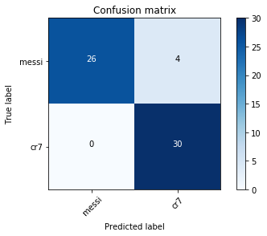

```python
preds = np.argmax(probs, axis=1)
probs = probs[:,1]
from sklearn.metrics import confusion_matrix
cm = confusion_matrix(y, preds)
plot_confusion_matrix(cm, data.classes)
```

```
Most incorrect Messi
```

[figure not shown]

```python
plot_val_with_title(most_by_correct(0, False), "Most incorrect Messi")
```

```
Most correct CR7
```

[figure not shown]

```python
plot_val_with_title(most_by_correct(1, True), "Most correct CR7")
```